# Capital Study: Data Visualization

Group 10

```r
#loading for analysis prepared data table
capital <- read.csv('capital_data.csv')
```

## Data Analysis - Original Study

For the main trials of our experiment we hold the following research hypotheses:

H1: The area under the curve (AUC) is larger for atypical trials compared to typical trials.

H2: The maximal absolute deviation (MAD) is larger for atypical trials compared to typical trials.

H3:Movement duration is longer for atypical trials compared to typical trials.

H4:The likelihood of obtaining different cluster types depends on the experimental conditions.

H5:The total categorisation response time is longer for atypical trials compared to typical trials.

H6:The movement initiation latency is longer for atypical trials compared to typical trials.

H7:The distance travelled in pixels is longer for atypical trials compared to typical trials.

# Data Vizualisation

H1: The area under the curve (AUC) is larger for atypical trials compared to typical trials.

```r
#Taking absolute AUC values, since negative AUC make no sense
capital$AUC_abs = abs(capital$AUC)

#We take the median, because it is less influenced by outliers
median_AUC <- capital %>%
  group_by(trial_type) %>%
  dplyr::summarize(AUC_median = median(AUC_abs, na.rm = TRUE))
median_AUC
```

```
## # A tibble: 2 x 2
##   trial_type AUC_median
##   <chr>           <dbl>
## 1 Atypical       39399
## 2 Typical        40139.
```

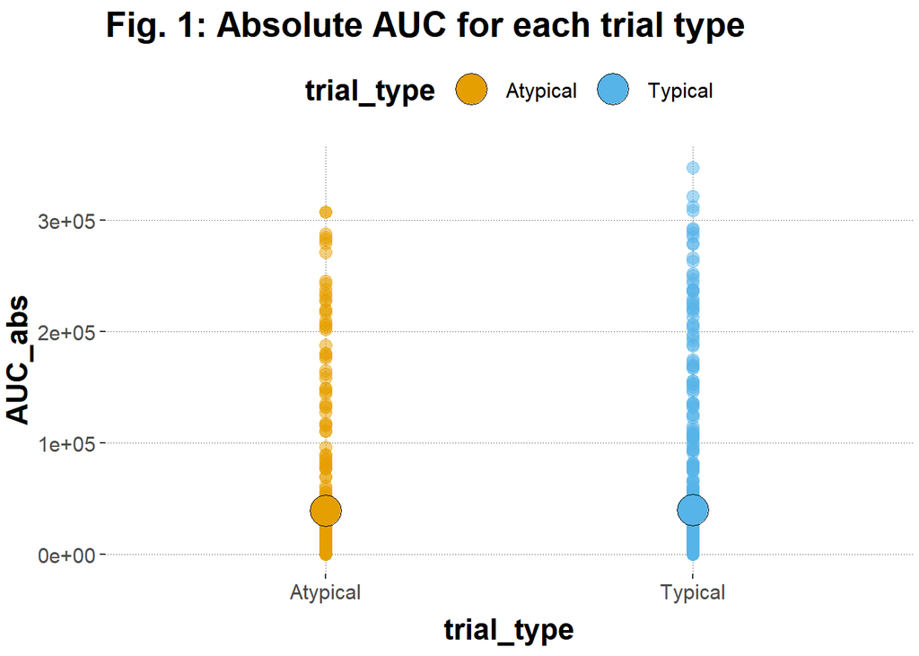

```r
#Plotting AUC_abs for each trial_type
ggplot(capital,
       aes(x = trial_type,
           y = AUC_abs,
           color = trial_type, fill = trial_type))+
  geom_point(alpha = 0.5, size = 3)+
  geom_point(data = median_AUC, aes(x= trial_type, y = AUC_median), color = "black", alpha = 1.0, size = 8, shape = 21)+
  geom_point(data = median_AUC, aes(x= trial_type, y = AUC_median, color = trial_type), alpha = 1.0, size = 7)+
  scale_y_continuous(limits = c(0,350000))+
   ggtitle("Fig. 1: Absolute AUC for each trial type")
```

Fig. 1: The point plot shows the ablsoute Area under the Curve (AUC_abs) values for the respective trial type. The smaller points represent the AUC_abs values for every trial and the big points show the medians of AUC_abs for each trial type. The median AUC_abs values for the respective trail types show no difference.

H2: The maximal absolute deviation (MAD) is larger for atypical trials compared to typical trials.

```r
#Taking absolute MAD values, since negative MAD make no sense
capital$MAD_abs = abs(capital$MAD)

#We take the median, because it is less influenced by outliers
median_MAD <- capital %>%
  group_by(trial_type) %>%
  dplyr::summarize(MAD_median = median(MAD_abs, na.rm = TRUE))
median_MAD
```

```
## # A tibble: 2 x 2
##   trial_type MAD_median
##   <chr>           <dbl>
## 1 Atypical         97.0
## 2 Typical          90.5
```

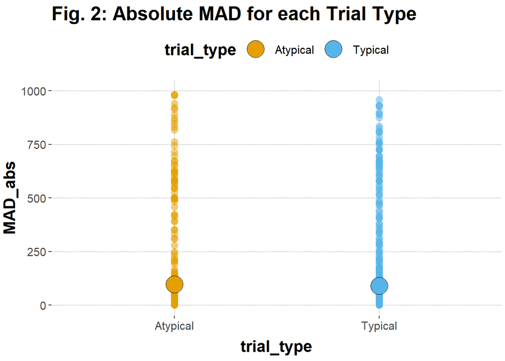

```r
#Plotting MAD_abs for each trial_type
ggplot(capital,
       aes(x = trial_type,
           y = MAD_abs,
           color = trial_type, fill = trial_type))+
  geom_point(alpha = 0.5, size = 3)+
  geom_point(data = median_MAD, aes(x= trial_type, y = MAD_median), color = "black", alpha = 1.0, size = 8, shape = 21)+
  geom_point(data = median_MAD, aes(x= trial_type, y = MAD_median, color = trial_type), alpha = 1.0, size = 7)+
  scale_y_continuous(limits = c(0,1000))+
   ggtitle("Fig. 2: Absolute MAD for each Trial Type")
```

Fig. 2: The point plot shows the ablsoute Maximum Absolute Deviation (MAD_abs) values for the respective trial type. The smaller points represent the MAD_abs values for every trial and the big points show the medians of MAD_abs for each trial type. The median MAD_abs values for the Atypical trial type is slightly higher than for the Typical trial type, wherefore this difference might be noteworthy.

H3:Movement duration is longer for atypical trials compared to typical trials.

```r
#log-tranforming mousetracking duration values for better handling -> there are no negative mousetracking duration
capital$mousetrackingDuration_log <- log(capital$mousetrackingDuration)

#We take the median, because it is less influenced by outliers
median_move_dur <- capital %>%
  group_by(trial_type) %>%
  dplyr::summarize(move_dur_median = median(mousetrackingDuration_log, na.rm = TRUE))
median_move_dur
```

```
## # A tibble: 2 x 2
##   trial_type move_dur_median
##   <chr>                <dbl>
## 1 Atypical              7.52
## 2 Typical               7.30
```

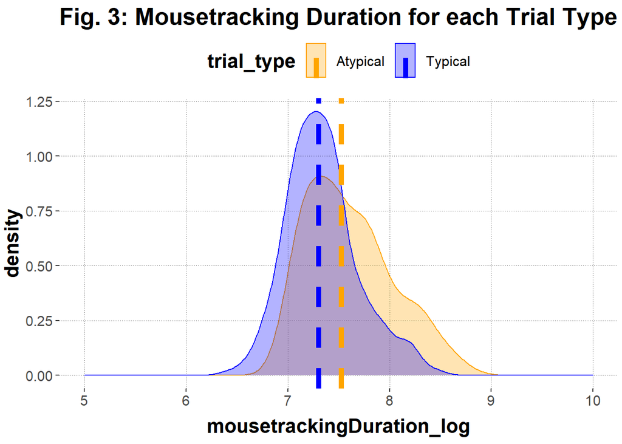

```r
#Plotting Mousetracking Duration for each trial type
ggplot(data = capital,
       aes(x = mousetrackingDuration_log,
           color = trial_type, fill = trial_type))+
  geom_density(alpha = 0.3)+
  #Adding mean RT values as a dashed line
  geom_vline(data= median_move_dur, aes(xintercept= move_dur_median, color= trial_type), linetype = "dashed", size = 2)+
  scale_fill_manual(values = c("orange", "blue"))+
  scale_color_manual(values = c("orange", "blue"))+
  scale_x_continuous(limits = c(5,10))+
   ggtitle("Fig. 3: Mousetracking Duration for each Trial Type")
```

Fig. 3: The graph shows a density plot of the data displaying the median log-transformed mousetracking duration (move_dur_median) for each trial type (dashed lines) and the distribution of log transformed mousetracking duration for each trial type of each trial (colored density distribution for respective trial type). The log transformed mousetracking duration values for each trial type are differently distributed. For the Typical trial type there is a high peak between [7,8] and the distribution is more narrow than for the Atypical trail type. The peak for the Atypical trial type is also around [7,8] but smaller. The distribution of log transformed mousetracking duration values for the Atypical trial type is also more spread out than for the Typical trial type. The median of log transformed mousetracking duration values for the Atypical trial type is larger than for the Typical trial type. This difference might not be noteworthy.

H4:The likelihood of obtaining different cluster types depends on the experimental conditions.

- Please view plots "Percentage of prototypes" and "Classification of Prototypes for Trial_Type" in file capital_data_cleaning under ##CLUSTER AGGREGATION & PROTOTYPE CLASSIFICATION.

H5:The total categorisation response time is longer for atypical trials compared to typical trials.

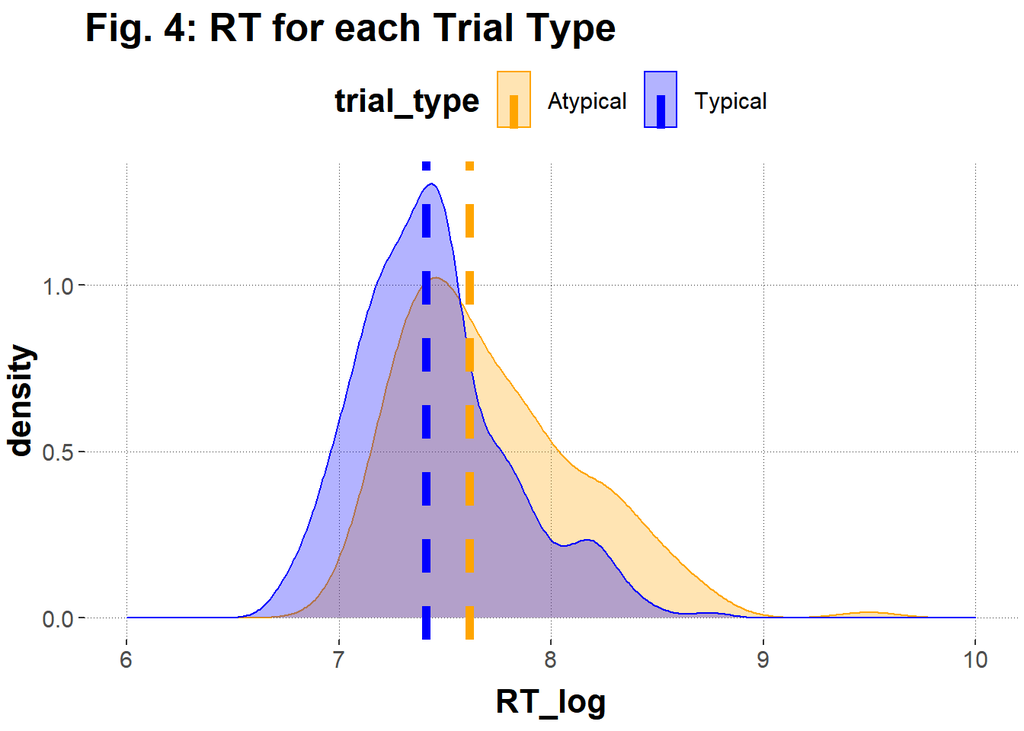

```r
#log-tranforming RT values for better handling -> there are no negative RT
capital$RT_log <- log(capital$RT)

#We take the median, because it is less influenced by outliers
median_RT <- capital %>%
  group_by(trial_type) %>%
  dplyr::summarize(RT_median = median(RT_log, na.rm = TRUE))

#Plotting differnce in RT for respective trail type in density plot
ggplot(data = capital,
       aes(x = RT_log,
           color = trial_type, fill = trial_type))+
  geom_density(alpha = 0.3)+
  #Adding mean RT values as a dashed line
  geom_vline(data= median_RT, aes(xintercept= RT_median, color= trial_type), linetype = "dashed", size = 2)+
  scale_fill_manual(values = c("orange", "blue"))+
  scale_color_manual(values = c("orange", "blue"))+
  scale_x_continuous(limits = c(6,10))+
  ggtitle("Fig. 4: RT for each Trial Type")
```

Fig. 4: The graph shows a density plot of the data displaying the median log-transformed reaction times (RT_median) for each trial type (dashed lines) and the distribution of RT_log for each trial type of each trial (colored density distribution for respective trial type). The RT_log values for each trial type are differently distributed. For the Typical trial type there is a high peak between [7,8] and the distribution is more narrow than for the Atypical trial type. The peak for the Atypical trial type is also around [7,8] but smaller. The distribution of RT_log values for the Atypical trial type is also more spread out than for the Typical trial type. The median of Rt_log values for the Atypical trial type is larger than for the Typical trial type. This difference might not be noteworthy.

H6:The movement initiation latency is longer for atypical trials compared to typical trials.

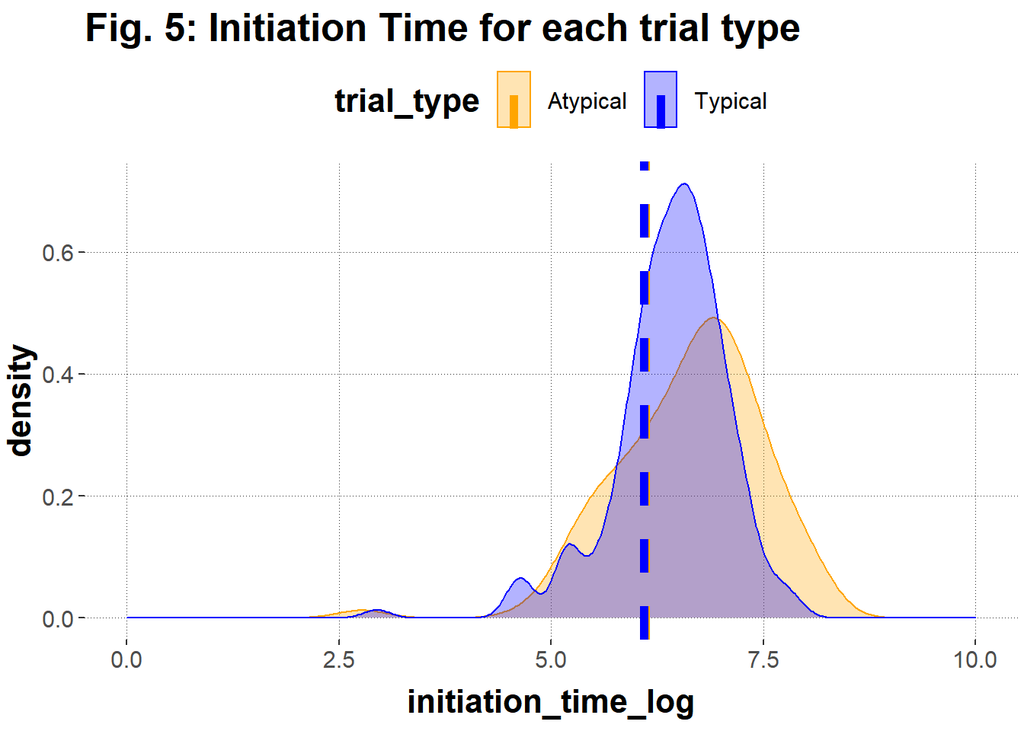

```r
#log-tranforming initiation time values for better handling -> there are no negative initiation times
capital$initiation_time_log <- log(capital$initiation_time)

#We take the median, because it is less influenced by outliers
median_ini_latency <- capital %>%
  group_by(trial_type) %>%
  dplyr::summarize(ini_latency_median = median(initiation_time_log, na.rm = TRUE))

#Plotting differnce in initiation times for respective trail type in density plot
ggplot(data = capital,
       aes(x = initiation_time_log,
           color = trial_type, fill = trial_type))+
  geom_density(alpha = 0.3)+
  #Adding mean RT values as a dashed line
  geom_vline(data= median_ini_latency, aes(xintercept= ini_latency_median, color= trial_type), linetype = "dashed", size = 2)+
  scale_fill_manual(values = c("orange", "blue"))+
  scale_color_manual(values = c("orange", "blue"))+
  scale_x_continuous(limits = c(-0,10))+
   ggtitle("Fig. 5: Initiation Time for each trial type")
```

Fig. 5: The graph shows a density plot of the data displaying the median log-transformed initiation time (ini_latency_median) for each trial type (dashed lines) and the distribution of log-transformed initiation times for each trial type of each trial (colored density distribution for respective trial type). The log initiation time values are differently distributed. The peak of Typical values is remarkably higher than the peak of Atypical values. The distribution for Atypical values is more spread out. There is no difference in the mean initiation times for the trial types.

H7:The distance travelled in pixels is longer for atypical trials compared to typical trials.

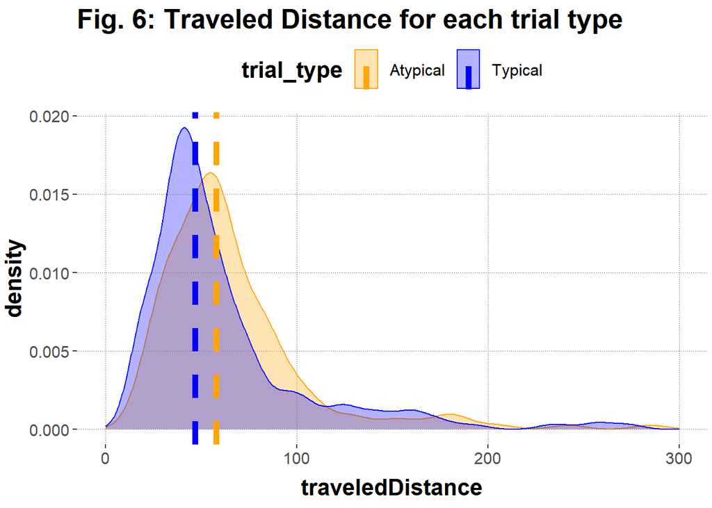

```r
#We take the median, because it is less influenced by outliers
median_travel_dis <- capital %>%
  group_by(trial_type) %>%
  dplyr::summarize(travel_dis_median = median(traveledDistance, na.rm = TRUE))

#Plotting differnce in traveled distance for respective trial type in density plot
ggplot(data = capital,
       aes(x = traveledDistance,
           color = trial_type, fill = trial_type))+
  geom_density(alpha = 0.3)+
  #Adding mean RT values as a dashed line
  geom_vline(data= median_travel_dis, aes(xintercept= travel_dis_median, color= trial_type), linetype = "dashed", size = 2)+
  scale_fill_manual(values = c("orange", "blue"))+
  scale_color_manual(values = c("orange", "blue"))+
  scale_x_continuous(limits = c(0,300))+
   ggtitle("Fig. 6: Traveled Distance for each trial type")
```

Fig. 6: The graph shows a density plot of the data displaying the median traveled distance (travel_dis__median) for each trial type (dashed lines) and the distribution of traveled distance for each trial type of each trial (colored density distribution for respective trial type). Both distributions have a peak between [0,100], whereas the peak for Typical values is higher than the peak for Atypical values. The median for Atypical values is larger than the median of Typical values. This difference might however not be noteworthy.